# Risk Factor Analysis

## Outcome Variable

**Outcome Variable:** swasted

## Predictor Variables

**Intervention Variable:** exclfeed6

**Adjustment Set:**

- arm
- sex
- brthmon
- W_mage
- meducyrs
- feducyrs
- hhwealth_quart
- hfoodsec
- W_mhtcm
- W_mwtkg
- W_mbmi
- vagbrth
- W_gagebrth
- W_birthwt
- W_birthlen
- W_nrooms
- W_nchldlt5
- month
- W_parity
- impfloor
- impsan
- safeh20
- delta_W_mage
- delta_meducyrs
- delta_feducyrs
- delta_hhwealth_quart
- delta_hfoodsec
- delta_W_mhtcm
- delta_W_mwtkg
- delta_W_mbmi
- delta_vagbrth
- delta_W_gagebrth
- delta_W_birthwt
- delta_W_birthlen
- delta_W_nrooms
- delta_W_nchldlt5
- delta_month
- delta_W_parity
- delta_impfloor
- delta_impsan
- delta_safeh20

## Stratifying Variables

The analysis was stratified on these variable(s):

- agecat
- studyid
- country

## Data Summary

| agecat | studyid | country | exclfeed6 | swasted | n_cell | n |
| --- | --- | --- | --- | --- | --- | --- |
| Birth | CMC-V-BCS-2002 | INDIA | 1 | 0 | 7 | 7 |
| Birth | CMC-V-BCS-2002 | INDIA | 1 | 1 | 0 | 7 |
| Birth | CMC-V-BCS-2002 | INDIA | 0 | 0 | 0 | 7 |
| Birth | CMC-V-BCS-2002 | INDIA | 0 | 1 | 0 | 7 |
| Birth | EE | PAKISTAN | 1 | 0 | 24 | 28 |
| Birth | EE | PAKISTAN | 1 | 1 | 0 | 28 |
| Birth | EE | PAKISTAN | 0 | 0 | 3 | 28 |
| Birth | EE | PAKISTAN | 0 | 1 | 1 | 28 |
| Birth | GMS-Nepal | NEPAL | 1 | 0 | 371 | 522 |
| Birth | GMS-Nepal | NEPAL | 1 | 1 | 19 | 522 |
| Birth | GMS-Nepal | NEPAL | 0 | 0 | 129 | 522 |
| Birth | GMS-Nepal | NEPAL | 0 | 1 | 3 | 522 |
| Birth | IRC | INDIA | 1 | 0 | 0 | 12 |
| Birth | IRC | INDIA | 1 | 1 | 0 | 12 |
| Birth | IRC | INDIA | 0 | 0 | 12 | 12 |
| Birth | IRC | INDIA | 0 | 1 | 0 | 12 |
| Birth | JiVitA-3 | BANGLADESH | 1 | 0 | 8209 | 10744 |
| Birth | JiVitA-3 | BANGLADESH | 1 | 1 | 172 | 10744 |
| Birth | JiVitA-3 | BANGLADESH | 0 | 0 | 2325 | 10744 |
| Birth | JiVitA-3 | BANGLADESH | 0 | 1 | 38 | 10744 |
| Birth | JiVitA-4 | BANGLADESH | 1 | 0 | 1780 | 2224 |
| Birth | JiVitA-4 | BANGLADESH | 1 | 1 | 19 | 2224 |
| Birth | JiVitA-4 | BANGLADESH | 0 | 0 | 415 | 2224 |
| Birth | JiVitA-4 | BANGLADESH | 0 | 1 | 10 | 2224 |
| Birth | Keneba | GAMBIA | 1 | 0 | 411 | 1327 |
| Birth | Keneba | GAMBIA | 1 | 1 | 39 | 1327 |
| Birth | Keneba | GAMBIA | 0 | 0 | 820 | 1327 |
| Birth | Keneba | GAMBIA | 0 | 1 | 57 | 1327 |
| Birth | MAL-ED | BANGLADESH | 1 | 0 | 29 | 194 |
| Birth | MAL-ED | BANGLADESH | 1 | 1 | 0 | 194 |

[output cut: 170 more lines]

The following strata were considered:

- agecat: 24 months, studyid: CMC-V-BCS-2002, country: INDIA
- agecat: 24 months, studyid: EE, country: PAKISTAN
- agecat: 24 months, studyid: GMS-Nepal, country: NEPAL
- agecat: 24 months, studyid: IRC, country: INDIA
- agecat: 24 months, studyid: JiVitA-3, country: BANGLADESH
- agecat: 24 months, studyid: JiVitA-4, country: BANGLADESH
- agecat: 24 months, studyid: Keneba, country: GAMBIA
- agecat: 24 months, studyid: LCNI-5, country: MALAWI
- agecat: 24 months, studyid: MAL-ED, country: BANGLADESH
- agecat: 24 months, studyid: MAL-ED, country: BRAZIL
- agecat: 24 months, studyid: MAL-ED, country: INDIA
- agecat: 24 months, studyid: MAL-ED, country: NEPAL
- agecat: 24 months, studyid: MAL-ED, country: PERU
- agecat: 24 months, studyid: MAL-ED, country: SOUTH AFRICA
- agecat: 24 months, studyid: MAL-ED, country: TANZANIA, UNITED REPUBLIC OF
- agecat: 24 months, studyid: PROVIDE, country: BANGLADESH
- agecat: 6 months, studyid: CMC-V-BCS-2002, country: INDIA
- agecat: 6 months, studyid: EE, country: PAKISTAN
- agecat: 6 months, studyid: GMS-Nepal, country: NEPAL
- agecat: 6 months, studyid: IRC, country: INDIA
- agecat: 6 months, studyid: JiVitA-3, country: BANGLADESH
- agecat: 6 months, studyid: JiVitA-4, country: BANGLADESH
- agecat: 6 months, studyid: Keneba, country: GAMBIA
- agecat: 6 months, studyid: LCNI-5, country: MALAWI
- agecat: 6 months, studyid: MAL-ED, country: BANGLADESH
- agecat: 6 months, studyid: MAL-ED, country: BRAZIL
- agecat: 6 months, studyid: MAL-ED, country: INDIA
- agecat: 6 months, studyid: MAL-ED, country: NEPAL
- agecat: 6 months, studyid: MAL-ED, country: PERU
- agecat: 6 months, studyid: MAL-ED, country: SOUTH AFRICA
- agecat: 6 months, studyid: MAL-ED, country: TANZANIA, UNITED REPUBLIC OF
- agecat: 6 months, studyid: PROVIDE, country: BANGLADESH
- agecat: 6 months, studyid: SAS-CompFeed, country: INDIA
- agecat: 6 months, studyid: SAS-FoodSuppl, country: INDIA
- agecat: Birth, studyid: CMC-V-BCS-2002, country: INDIA
- agecat: Birth, studyid: EE, country: PAKISTAN
- agecat: Birth, studyid: GMS-Nepal, country: NEPAL
- agecat: Birth, studyid: IRC, country: INDIA
- agecat: Birth, studyid: JiVitA-3, country: BANGLADESH
- agecat: Birth, studyid: JiVitA-4, country: BANGLADESH
- agecat: Birth, studyid: Keneba, country: GAMBIA
- agecat: Birth, studyid: MAL-ED, country: BANGLADESH
- agecat: Birth, studyid: MAL-ED, country: BRAZIL
- agecat: Birth, studyid: MAL-ED, country: INDIA
- agecat: Birth, studyid: MAL-ED, country: NEPAL
- agecat: Birth, studyid: MAL-ED, country: PERU
- agecat: Birth, studyid: MAL-ED, country: SOUTH AFRICA
- agecat: Birth, studyid: MAL-ED, country: TANZANIA, UNITED REPUBLIC OF
- agecat: Birth, studyid: PROVIDE, country: BANGLADESH
- agecat: Birth, studyid: SAS-CompFeed, country: INDIA

### Dropped Strata

Some strata were dropped due to rare outcomes:

- agecat: Birth, studyid: CMC-V-BCS-2002, country: INDIA
- agecat: Birth, studyid: EE, country: PAKISTAN
- agecat: Birth, studyid: GMS-Nepal, country: NEPAL
- agecat: Birth, studyid: IRC, country: INDIA
- agecat: Birth, studyid: MAL-ED, country: BANGLADESH
- agecat: Birth, studyid: MAL-ED, country: BRAZIL
- agecat: Birth, studyid: MAL-ED, country: INDIA
- agecat: Birth, studyid: MAL-ED, country: NEPAL
- agecat: Birth, studyid: MAL-ED, country: PERU
- agecat: Birth, studyid: MAL-ED, country: SOUTH AFRICA
- agecat: Birth, studyid: MAL-ED, country: TANZANIA, UNITED REPUBLIC OF
- agecat: Birth, studyid: PROVIDE, country: BANGLADESH
- agecat: Birth, studyid: SAS-CompFeed, country: INDIA
- agecat: 6 months, studyid: CMC-V-BCS-2002, country: INDIA
- agecat: 6 months, studyid: EE, country: PAKISTAN
- agecat: 6 months, studyid: GMS-Nepal, country: NEPAL
- agecat: 6 months, studyid: IRC, country: INDIA
- agecat: 6 months, studyid: LCNI-5, country: MALAWI
- agecat: 6 months, studyid: MAL-ED, country: BANGLADESH
- agecat: 6 months, studyid: MAL-ED, country: BRAZIL
- agecat: 6 months, studyid: MAL-ED, country: INDIA
- agecat: 6 months, studyid: MAL-ED, country: NEPAL
- agecat: 6 months, studyid: MAL-ED, country: PERU
- agecat: 6 months, studyid: MAL-ED, country: SOUTH AFRICA
- agecat: 6 months, studyid: MAL-ED, country: TANZANIA, UNITED REPUBLIC OF
- agecat: 6 months, studyid: PROVIDE, country: BANGLADESH
- agecat: 6 months, studyid: SAS-CompFeed, country: INDIA
- agecat: 6 months, studyid: SAS-FoodSuppl, country: INDIA
- agecat: 24 months, studyid: CMC-V-BCS-2002, country: INDIA
- agecat: 24 months, studyid: EE, country: PAKISTAN
- agecat: 24 months, studyid: IRC, country: INDIA
- agecat: 24 months, studyid: LCNI-5, country: MALAWI
- agecat: 24 months, studyid: MAL-ED, country: BANGLADESH
- agecat: 24 months, studyid: MAL-ED, country: BRAZIL
- agecat: 24 months, studyid: MAL-ED, country: INDIA
- agecat: 24 months, studyid: MAL-ED, country: NEPAL
- agecat: 24 months, studyid: MAL-ED, country: PERU
- agecat: 24 months, studyid: MAL-ED, country: SOUTH AFRICA
- agecat: 24 months, studyid: MAL-ED, country: TANZANIA, UNITED REPUBLIC OF
- agecat: 24 months, studyid: PROVIDE, country: BANGLADESH

## Methods Detail

We’re interested in the causal parameters $E[Y_a]$ for all values of $a \in \mathcal{A}$. These parameters represent the mean outcome if, possibly contrary to fact, we intervened to set all units to have $A=a$. Under the randomization and positivity assumptions, these are identified by the statistical parameters $\psi_a=E_W[E_{Y|A,W}(Y|A=a,W)]$. In addition, we’re interested in the mean of $Y$, $E[Y]$ under no intervention (the observed mean). We will estimate these parameters by using SuperLearner to fit the relevant likelihood factors – $E_{Y|A,W}(Y|A=a,W)$ and $p(A=a|W)$, and then updating our likelihood fit using a joint TMLE.

For unadjusted analyses ($W=\{\}$), initial likelihoods were estimated using Lrnr_glm to estimate the simple $E(Y|A)$ and Lrnr_mean to estimate $p(A)$. For adjusted analyses, a small library containing Lrnr_glmnet, Lrnr_xgboost, and Lrnr_mean was used.

Having estimated these parameters, we will then use the delta method to estimate relative risks and attributable risks relative to a prespecified baseline level of $A$.

# Results Detail

## Results Plots

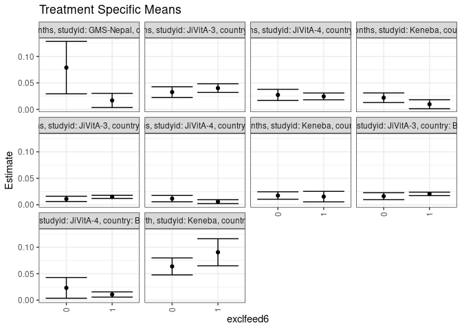

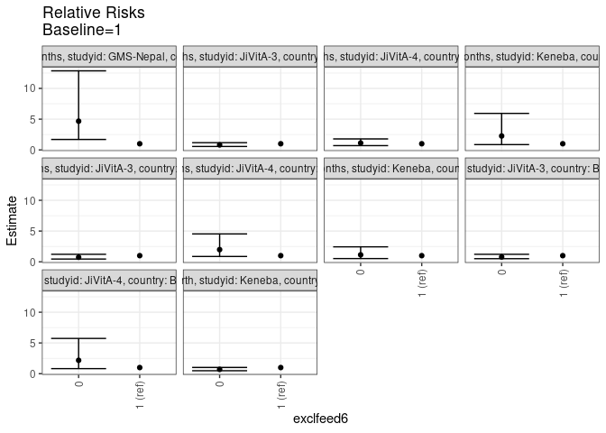

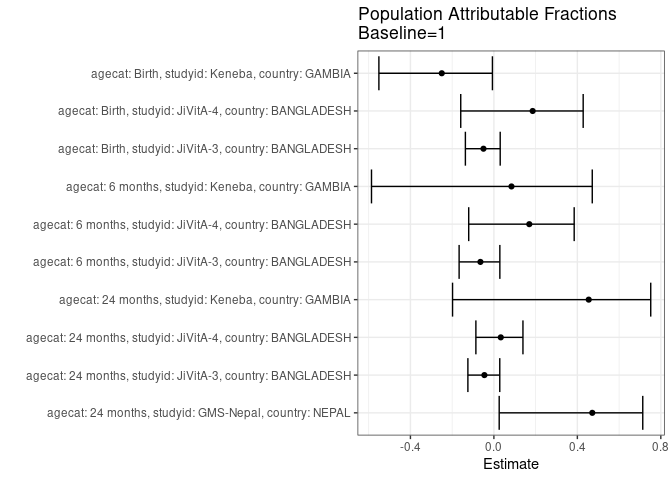

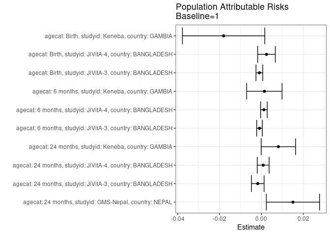

## Results Table

### Parameter: TSM

| agecat | studyid | country | intervention_level | baseline_level | estimate | ci_lower | ci_upper |
| --- | --- | --- | --- | --- | --- | --- | --- |
| Birth | JiVitA-3 | BANGLADESH | 1 | NA | 0.0205211 | 0.0172664 | 0.0237757 |
| Birth | JiVitA-3 | BANGLADESH | 0 | NA | 0.0161372 | 0.0095770 | 0.0226973 |
| Birth | JiVitA-4 | BANGLADESH | 1 | NA | 0.0106173 | 0.0056794 | 0.0155551 |
| Birth | JiVitA-4 | BANGLADESH | 0 | NA | 0.0231380 | 0.0035340 | 0.0427421 |
| Birth | Keneba | GAMBIA | 1 | NA | 0.0904147 | 0.0648144 | 0.1160149 |
| Birth | Keneba | GAMBIA | 0 | NA | 0.0636994 | 0.0476426 | 0.0797563 |
| 6 months | JiVitA-3 | BANGLADESH | 1 | NA | 0.0148666 | 0.0119612 | 0.0177719 |
| 6 months | JiVitA-3 | BANGLADESH | 0 | NA | 0.0109636 | 0.0059055 | 0.0160217 |
| 6 months | JiVitA-4 | BANGLADESH | 1 | NA | 0.0058268 | 0.0021147 | 0.0095390 |
| 6 months | JiVitA-4 | BANGLADESH | 0 | NA | 0.0115430 | 0.0055409 | 0.0175451 |
| 6 months | Keneba | GAMBIA | 1 | NA | 0.0153584 | 0.0053992 | 0.0253176 |
| 6 months | Keneba | GAMBIA | 0 | NA | 0.0173979 | 0.0103480 | 0.0244478 |
| 24 months | GMS-Nepal | NEPAL | 1 | NA | 0.0169014 | 0.0034782 | 0.0303246 |
| 24 months | GMS-Nepal | NEPAL | 0 | NA | 0.0789474 | 0.0293943 | 0.1285004 |
| 24 months | JiVitA-3 | BANGLADESH | 1 | NA | 0.0402332 | 0.0320318 | 0.0484347 |
| 24 months | JiVitA-3 | BANGLADESH | 0 | NA | 0.0326001 | 0.0225427 | 0.0426574 |
| 24 months | JiVitA-4 | BANGLADESH | 1 | NA | 0.0244976 | 0.0180904 | 0.0309048 |
| 24 months | JiVitA-4 | BANGLADESH | 0 | NA | 0.0273395 | 0.0168295 | 0.0378495 |
| 24 months | Keneba | GAMBIA | 1 | NA | 0.0097276 | 0.0012399 | 0.0182153 |
| 24 months | Keneba | GAMBIA | 0 | NA | 0.0220000 | 0.0129056 | 0.0310944 |

### Parameter: E(Y)

| agecat | studyid | country | intervention_level | baseline_level | estimate | ci_lower | ci_upper |
| --- | --- | --- | --- | --- | --- | --- | --- |
| Birth | JiVitA-3 | BANGLADESH | NA | NA | 0.0195458 | 0.0166489 | 0.0224427 |
| Birth | JiVitA-4 | BANGLADESH | NA | NA | 0.0130396 | 0.0073461 | 0.0187330 |
| Birth | Keneba | GAMBIA | NA | NA | 0.0723436 | 0.0584002 | 0.0862871 |
| 6 months | JiVitA-3 | BANGLADESH | NA | NA | 0.0139648 | 0.0114567 | 0.0164729 |
| 6 months | JiVitA-4 | BANGLADESH | NA | NA | 0.0070175 | 0.0038738 | 0.0101612 |
| 6 months | Keneba | GAMBIA | NA | NA | 0.0167715 | 0.0110080 | 0.0225350 |
| 24 months | GMS-Nepal | NEPAL | NA | NA | 0.0319829 | 0.0160416 | 0.0479243 |
| 24 months | JiVitA-3 | BANGLADESH | NA | NA | 0.0384843 | 0.0318086 | 0.0451600 |
| 24 months | JiVitA-4 | BANGLADESH | NA | NA | 0.0253346 | 0.0198022 | 0.0308670 |
| 24 months | Keneba | GAMBIA | NA | NA | 0.0178336 | 0.0111649 | 0.0245022 |

### Parameter: RR

| agecat | studyid | country | intervention_level | baseline_level | estimate | ci_lower | ci_upper |
| --- | --- | --- | --- | --- | --- | --- | --- |
| Birth | JiVitA-3 | BANGLADESH | 1 | 1 | 1.0000000 | 1.0000000 | 1.000000 |
| Birth | JiVitA-3 | BANGLADESH | 0 | 1 | 0.7863708 | 0.5070710 | 1.219512 |
| Birth | JiVitA-4 | BANGLADESH | 1 | 1 | 1.0000000 | 1.0000000 | 1.000000 |
| Birth | JiVitA-4 | BANGLADESH | 0 | 1 | 2.1792822 | 0.8278166 | 5.737105 |
| Birth | Keneba | GAMBIA | 1 | 1 | 1.0000000 | 1.0000000 | 1.000000 |
| Birth | Keneba | GAMBIA | 0 | 1 | 0.7045254 | 0.4875639 | 1.018033 |
| 6 months | JiVitA-3 | BANGLADESH | 1 | 1 | 1.0000000 | 1.0000000 | 1.000000 |
| 6 months | JiVitA-3 | BANGLADESH | 0 | 1 | 0.7374675 | 0.4453655 | 1.221151 |
| 6 months | JiVitA-4 | BANGLADESH | 1 | 1 | 1.0000000 | 1.0000000 | 1.000000 |
| 6 months | JiVitA-4 | BANGLADESH | 0 | 1 | 1.9810144 | 0.8657014 | 4.533224 |
| 6 months | Keneba | GAMBIA | 1 | 1 | 1.0000000 | 1.0000000 | 1.000000 |
| 6 months | Keneba | GAMBIA | 0 | 1 | 1.1327954 | 0.5273112 | 2.433526 |
| 24 months | GMS-Nepal | NEPAL | 1 | 1 | 1.0000000 | 1.0000000 | 1.000000 |
| 24 months | GMS-Nepal | NEPAL | 0 | 1 | 4.6710526 | 1.6973880 | 12.854299 |
| 24 months | JiVitA-3 | BANGLADESH | 1 | 1 | 1.0000000 | 1.0000000 | 1.000000 |
| 24 months | JiVitA-3 | BANGLADESH | 0 | 1 | 0.8102771 | 0.5585886 | 1.175371 |
| 24 months | JiVitA-4 | BANGLADESH | 1 | 1 | 1.0000000 | 1.0000000 | 1.000000 |
| 24 months | JiVitA-4 | BANGLADESH | 0 | 1 | 1.1160069 | 0.6974601 | 1.785724 |
| 24 months | Keneba | GAMBIA | 1 | 1 | 1.0000000 | 1.0000000 | 1.000000 |
| 24 months | Keneba | GAMBIA | 0 | 1 | 2.2616000 | 0.8611947 | 5.939231 |

### Parameter: PAR

| agecat | studyid | country | intervention_level | baseline_level | estimate | ci_lower | ci_upper |
| --- | --- | --- | --- | --- | --- | --- | --- |
| Birth | JiVitA-3 | BANGLADESH | 1 | NA | -0.0009753 | -0.0025914 | 0.0006409 |
| Birth | JiVitA-4 | BANGLADESH | 1 | NA | 0.0024223 | -0.0017859 | 0.0066305 |
| Birth | Keneba | GAMBIA | 1 | NA | -0.0180710 | -0.0377589 | 0.0016169 |
| 6 months | JiVitA-3 | BANGLADESH | 1 | NA | -0.0009018 | -0.0022605 | 0.0004570 |
| 6 months | JiVitA-4 | BANGLADESH | 1 | NA | 0.0011907 | -0.0004025 | 0.0027840 |
| 6 months | Keneba | GAMBIA | 1 | NA | 0.0014131 | -0.0070414 | 0.0098676 |
| 24 months | GMS-Nepal | NEPAL | 1 | NA | 0.0150815 | 0.0023717 | 0.0277913 |
| 24 months | JiVitA-3 | BANGLADESH | 1 | NA | -0.0017489 | -0.0047739 | 0.0012761 |
| 24 months | JiVitA-4 | BANGLADESH | 1 | NA | 0.0008370 | -0.0019941 | 0.0036681 |
| 24 months | Keneba | GAMBIA | 1 | NA | 0.0081059 | -0.0001158 | 0.0163277 |

### Parameter: PAF

| agecat | studyid | country | intervention_level | baseline_level | estimate | ci_lower | ci_upper |
| --- | --- | --- | --- | --- | --- | --- | --- |
| Birth | JiVitA-3 | BANGLADESH | 1 | NA | -0.0498964 | -0.1366328 | 0.0302212 |
| Birth | JiVitA-4 | BANGLADESH | 1 | NA | 0.1857653 | -0.1589094 | 0.4279292 |
| Birth | Keneba | GAMBIA | 1 | NA | -0.2497944 | -0.5511319 | -0.0069975 |
| 6 months | JiVitA-3 | BANGLADESH | 1 | NA | -0.0645747 | -0.1666500 | 0.0285696 |
| 6 months | JiVitA-4 | BANGLADESH | 1 | NA | 0.1696769 | -0.1206991 | 0.3848157 |
| 6 months | Keneba | GAMBIA | 1 | NA | 0.0842577 | -0.5865784 | 0.4714513 |
| 24 months | GMS-Nepal | NEPAL | 1 | NA | 0.4715493 | 0.0254393 | 0.7134502 |
| 24 months | JiVitA-3 | BANGLADESH | 1 | NA | -0.0454447 | -0.1246203 | 0.0281568 |
| 24 months | JiVitA-4 | BANGLADESH | 1 | NA | 0.0330379 | -0.0863099 | 0.1392735 |
| 24 months | Keneba | GAMBIA | 1 | NA | 0.4545324 | -0.1981385 | 0.7516690 |